# **Marketing Campaign Analysis**

### **2.3 How This Affects the Business**

The segmentation transforms the business's marketing approach from one-size-fits-all to precision-targeted:

- **Premium Enthusiasts (25.3%)** receive exclusive catalog mailings, wine/meat cross-sells, and VIP loyalty treatment - driving higher per-customer revenue from an already responsive group.
- **Moderate Mainstream (27.9%)** receive omnichannel campaigns focused on category expansion and upselling - the growth engine for moving mid-tier customers toward premium behavior.
- **Budget Families (46.9%)** receive digital deal alerts and family-value bundles - maintaining engagement with the largest segment through price-appropriate channels.

This approach means marketing dollars are concentrated where ROI is highest (Premium receives 50% of budget despite being 25% of customers), while no segment is neglected.

### **Import Libraries and Load Data**

```python
!pip install scikit-learn-extra
```

**Note**: After running, restart the runtime, then continue.

```python
!pip install numpy==1.26.0
```

```python
%matplotlib inline
import numpy as np
import pandas as pd
import matplotlib.pyplot as plt
import seaborn as sns
from sklearn.preprocessing import StandardScaler, LabelEncoder
from sklearn.decomposition import PCA
from sklearn.manifold import TSNE
from sklearn.cluster import KMeans, DBSCAN, AgglomerativeClustering
from sklearn_extra.cluster import KMedoids
from sklearn.mixture import GaussianMixture
from sklearn.metrics import silhouette_score, silhouette_samples
from scipy.spatial.distance import cdist, pdist
from scipy.cluster.hierarchy import linkage, dendrogram, cophenet
import warnings
warnings.filterwarnings('ignore')

sns.set_style("whitegrid")
plt.rcParams['figure.dpi'] = 120
plt.rcParams['font.size'] = 11
print("All libraries loaded.")
```

```
All libraries loaded.
```

### **Data Overview**

```python
# Load data
# Load the marketing campaign dataset
data = pd.read_csv("marketing_campaign.csv")
print(f"Dataset shape: {data.shape[0]} rows x {data.shape[1]} columns\n")
data.head()
```

```
Dataset shape: 2240 rows x 27 columns
```

|  | ID | Year_Birth | Education | Marital_Status | Income | Kidhome | Teenhome | Dt_Customer | Recency | MntWines | ... | NumCatalogPurchases | NumStorePurchases | NumWebVisitsMonth | AcceptedCmp3 | AcceptedCmp4 | AcceptedCmp5 | AcceptedCmp1 | AcceptedCmp2 | Complain | Response |
| --- | --- | --- | --- | --- | --- | --- | --- | --- | --- | --- | --- | --- | --- | --- | --- | --- | --- | --- | --- | --- | --- |
| 0 | 5524 | 1957 | Graduation | Single | 58138.0 | 0 | 0 | 04-09-2012 | 58 | 635 | ... | 10 | 4 | 7 | 0 | 0 | 0 | 0 | 0 | 0 | 1 |
| 1 | 2174 | 1954 | Graduation | Single | 46344.0 | 1 | 1 | 08-03-2014 | 38 | 11 | ... | 1 | 2 | 5 | 0 | 0 | 0 | 0 | 0 | 0 | 0 |
| 2 | 4141 | 1965 | Graduation | Together | 71613.0 | 0 | 0 | 21-08-2013 | 26 | 426 | ... | 2 | 10 | 4 | 0 | 0 | 0 | 0 | 0 | 0 | 0 |
| 3 | 6182 | 1984 | Graduation | Together | 26646.0 | 1 | 0 | 10-02-2014 | 26 | 11 | ... | 0 | 4 | 6 | 0 | 0 | 0 | 0 | 0 | 0 | 0 |
| 4 | 5324 | 1981 | PhD | Married | 58293.0 | 1 | 0 | 19-01-2014 | 94 | 173 | ... | 3 | 6 | 5 | 0 | 0 | 0 | 0 | 0 | 0 | 0 |

5 rows × 27 columns

```python
# Shape and data types
data.info()
```

```
<class 'pandas.core.frame.DataFrame'>
RangeIndex: 2240 entries, 0 to 2239
Data columns (total 27 columns):
 #   Column               Non-Null Count  Dtype
---  ------               --------------  -----
 0   ID                   2240 non-null   int64
 1   Year_Birth           2240 non-null   int64
 2   Education            2240 non-null   object
 3   Marital_Status       2240 non-null   object
 4   Income               2216 non-null   float64
 5   Kidhome              2240 non-null   int64
 6   Teenhome             2240 non-null   int64
 7   Dt_Customer          2240 non-null   object
 8   Recency              2240 non-null   int64
 9   MntWines             2240 non-null   int64
```

[output cut: 19 more lines]

```python
# Missing values analysis
missing = data.isnull().sum()
print("Columns with missing values:")
print(missing[missing > 0])
print(f"\nTotal missing: {missing.sum()} out of {data.size} values ({missing.sum()/data.size*100:.4f}%)")
print(f"\nOnly the 'Income' column has missing data - 24 records (1.07%).")
print("Since Income is right-skewed, we will impute with the median after outlier removal.")
```

```
Columns with missing values:
Income    24
dtype: int64

Total missing: 24 out of 60480 values (0.0397%)

Only the 'Income' column has missing data - 24 records (1.07%).
Since Income is right-skewed, we will impute with the median after outlier removal.
```

```python
# Check duplicates
print(f"Duplicate rows: {data.duplicated().sum()}")
print(f"Duplicate IDs:  {data['ID'].duplicated().sum()}")
print("\nNo duplicates found - all records are unique.")
```

```
Duplicate rows: 0
Duplicate IDs:  0

No duplicates found - all records are unique.
```

```python
# Drop ID column - unique identifier with no analytical value
data.drop(columns=['ID'], inplace=True)
print(f"Shape after dropping ID: {data.shape}")
```

```
Shape after dropping ID: (2240, 26)
```

#### **Observations:** 2,240 records, 26 features, 24 missing Income values (1.07%), no duplicates.

### **Exploratory Data Analysis**

```python
# Numerical summary statistics
data.describe().T
```

|  | count | mean | std | min | 25% | 50% | 75% | max |
| --- | --- | --- | --- | --- | --- | --- | --- | --- |
| Year_Birth | 2240.0 | 1968.805804 | 11.984069 | 1893.0 | 1959.00 | 1970.0 | 1977.00 | 1996.0 |
| Income | 2216.0 | 52247.251354 | 25173.076661 | 1730.0 | 35303.00 | 51381.5 | 68522.00 | 666666.0 |
| Kidhome | 2240.0 | 0.444196 | 0.538398 | 0.0 | 0.00 | 0.0 | 1.00 | 2.0 |
| Teenhome | 2240.0 | 0.506250 | 0.544538 | 0.0 | 0.00 | 0.0 | 1.00 | 2.0 |
| Recency | 2240.0 | 49.109375 | 28.962453 | 0.0 | 24.00 | 49.0 | 74.00 | 99.0 |
| MntWines | 2240.0 | 303.935714 | 336.597393 | 0.0 | 23.75 | 173.5 | 504.25 | 1493.0 |
| MntFruits | 2240.0 | 26.302232 | 39.773434 | 0.0 | 1.00 | 8.0 | 33.00 | 199.0 |
| MntMeatProducts | 2240.0 | 166.950000 | 225.715373 | 0.0 | 16.00 | 67.0 | 232.00 | 1725.0 |
| MntFishProducts | 2240.0 | 37.525446 | 54.628979 | 0.0 | 3.00 | 12.0 | 50.00 | 259.0 |
| MntSweetProducts | 2240.0 | 27.062946 | 41.280498 | 0.0 | 1.00 | 8.0 | 33.00 | 263.0 |
| MntGoldProds | 2240.0 | 44.021875 | 52.167439 | 0.0 | 9.00 | 24.0 | 56.00 | 362.0 |
| NumDealsPurchases | 2240.0 | 2.325000 | 1.932238 | 0.0 | 1.00 | 2.0 | 3.00 | 15.0 |
| NumWebPurchases | 2240.0 | 4.084821 | 2.778714 | 0.0 | 2.00 | 4.0 | 6.00 | 27.0 |
| NumCatalogPurchases | 2240.0 | 2.662054 | 2.923101 | 0.0 | 0.00 | 2.0 | 4.00 | 28.0 |
| NumStorePurchases | 2240.0 | 5.790179 | 3.250958 | 0.0 | 3.00 | 5.0 | 8.00 | 13.0 |
| NumWebVisitsMonth | 2240.0 | 5.316518 | 2.426645 | 0.0 | 3.00 | 6.0 | 7.00 | 20.0 |
| AcceptedCmp3 | 2240.0 | 0.072768 | 0.259813 | 0.0 | 0.00 | 0.0 | 0.00 | 1.0 |
| AcceptedCmp4 | 2240.0 | 0.074554 | 0.262728 | 0.0 | 0.00 | 0.0 | 0.00 | 1.0 |
| AcceptedCmp5 | 2240.0 | 0.072768 | 0.259813 | 0.0 | 0.00 | 0.0 | 0.00 | 1.0 |
| AcceptedCmp1 | 2240.0 | 0.064286 | 0.245316 | 0.0 | 0.00 | 0.0 | 0.00 | 1.0 |
| AcceptedCmp2 | 2240.0 | 0.012946 | 0.113069 | 0.0 | 0.00 | 0.0 | 0.00 | 1.0 |
| Complain | 2240.0 | 0.009375 | 0.096391 | 0.0 | 0.00 | 0.0 | 0.00 | 1.0 |
| Response | 2240.0 | 0.149107 | 0.356274 | 0.0 | 0.00 | 0.0 | 0.00 | 1.0 |

```python
# Explore categorical variables
cat_cols = ["Education", "Marital_Status", "Kidhome", "Teenhome", "Complain"]
for col in cat_cols:
    print(f"\n{'='*50}")
    print(f"{col} - Unique values: {data[col].nunique()}")
    print(data[col].value_counts())
```

```
==================================================
Education - Unique values: 5
Education
Graduation    1127
PhD            486
Master         370
2n Cycle       203
Basic           54
Name: count, dtype: int64

==================================================
Marital_Status - Unique values: 8
Marital_Status
Married     864
Together    580
Single      480
Divorced    232
Widow        77
Alone         3
Absurd        2
YOLO          2
Name: count, dtype: int64

==================================================
Kidhome - Unique values: 3
Kidhome
0    1293
1     899
2      48
Name: count, dtype: int64

==================================================
Teenhome - Unique values: 3
Teenhome
0    1158
1    1030
2      52
Name: count, dtype: int64

==================================================
Complain - Unique values: 2
Complain
0    2219
1      21
Name: count, dtype: int64
```

```python
# Consolidate categories
# Education: "2n Cycle" is equivalent to Master-level in some EU systems - merge them
data["Education"] = data["Education"].replace({"2n Cycle": "Master"})

# Marital_Status: "Alone", "Absurd", "YOLO" have <5 records each - merge into "Single"
data["Marital_Status"] = data["Marital_Status"].replace({"Alone": "Single", "Absurd": "Single", "YOLO": "Single"})

print("Education after consolidation:")
print(data["Education"].value_counts())
print("\nMarital_Status after consolidation:")
print(data["Marital_Status"].value_counts())
```

```
Education after consolidation:
Education
Graduation    1127
Master         573
PhD            486
Basic           54
Name: count, dtype: int64

Marital_Status after consolidation:
Marital_Status
Married     864
Together    580
Single      487
Divorced    232
Widow        77
Name: count, dtype: int64
```

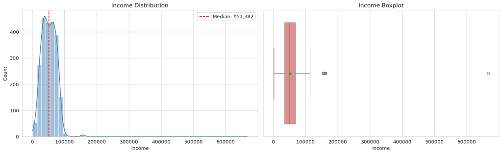

```
Income range: $1,730 - $666,666
One extreme outlier at $666,666 is clearly erroneous data.
```

```python
# Income distribution - histogram and boxplot
fig, axes = plt.subplots(1, 2, figsize=(16, 5))
sns.histplot(data['Income'].dropna(), kde=True, bins=50, ax=axes[0], color='steelblue')
axes[0].set_title('Income Distribution')
axes[0].axvline(data['Income'].median(), color='red', linestyle='--', label=f"Median: ${data['Income'].median():,.0f}")
axes[0].legend()

sns.boxplot(x=data['Income'], ax=axes[1], showmeans=True, color='lightcoral')
axes[1].set_title('Income Boxplot')
plt.tight_layout()
plt.show()

print(f"Income range: ${data['Income'].min():,.0f} - ${data['Income'].max():,.0f}")
print(f"One extreme outlier at ${data['Income'].max():,.0f} is clearly erroneous data.")
```

```python
# Outlier treatment
Q1 = data['Income'].quantile(0.25)
Q3 = data['Income'].quantile(0.75)
IQR = Q3 - Q1
upper_whisker = Q3 + 1.5 * IQR
print(f"Q1: {Q1:,.0f} | Q3: {Q3:,.0f} | IQR: {IQR:,.0f} | Upper Whisker: {upper_whisker:,.0f}")
print(f"99.5th percentile: ${data['Income'].quantile(0.995):,.0f}")

# Drop extreme outlier ($666,666 - data entry error)
extreme_idx = data[data['Income'] > 600000].index
print(f"\nDropping {len(extreme_idx)} extreme outlier(s) with Income > $600K")
data.drop(index=extreme_idx, inplace=True)
print(f"Shape after removal: {data.shape}")
```

```
Q1: 35,303 | Q3: 68,522 | IQR: 33,219 | Upper Whisker: 118,350
99.5th percentile: $102,146

Dropping 1 extreme outlier(s) with Income > $600K
Shape after removal: (2239, 26)
```

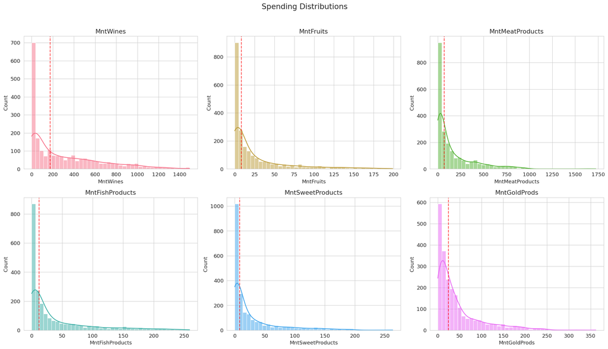

```
All spending variables are heavily right-skewed.
Most customers spend modestly, with a long tail of high spenders.
```

```python
# Spending distributions across all 6 product categories
spend_cols = ['MntWines', 'MntFruits', 'MntMeatProducts', 'MntFishProducts', 'MntSweetProducts', 'MntGoldProds']

fig, axes = plt.subplots(2, 3, figsize=(18, 10))
for i, col in enumerate(spend_cols):
    ax = axes[i//3, i%3]
    sns.histplot(data[col], kde=True, bins=40, ax=ax, color=sns.color_palette("husl", 6)[i])
    ax.set_title(col)
    ax.axvline(data[col].median(), color='red', linestyle='--', alpha=0.7)
plt.suptitle('Spending Distributions', fontsize=16, y=1.02)
plt.tight_layout()
plt.show()

print("All spending variables are heavily right-skewed.")
print("Most customers spend modestly, with a long tail of high spenders.")
```

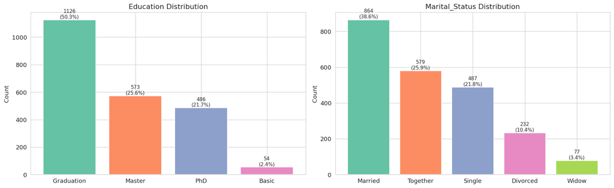

```python
# Categorical distributions with percentages
fig, axes = plt.subplots(1, 2, figsize=(16, 5))
for i, col in enumerate(['Education', 'Marital_Status']):
    ax = axes[i]
    counts = data[col].value_counts()
    bars = ax.bar(counts.index, counts.values, color=sns.color_palette("Set2", len(counts)))
    for bar, val in zip(bars, counts.values):
        ax.text(bar.get_x() + bar.get_width()/2, bar.get_height() + 10,
                f'{val}\n({val/len(data)*100:.1f}%)', ha='center', fontsize=9)
    ax.set_title(f'{col} Distribution')
    ax.set_ylabel('Count')
plt.tight_layout()
plt.show()
```

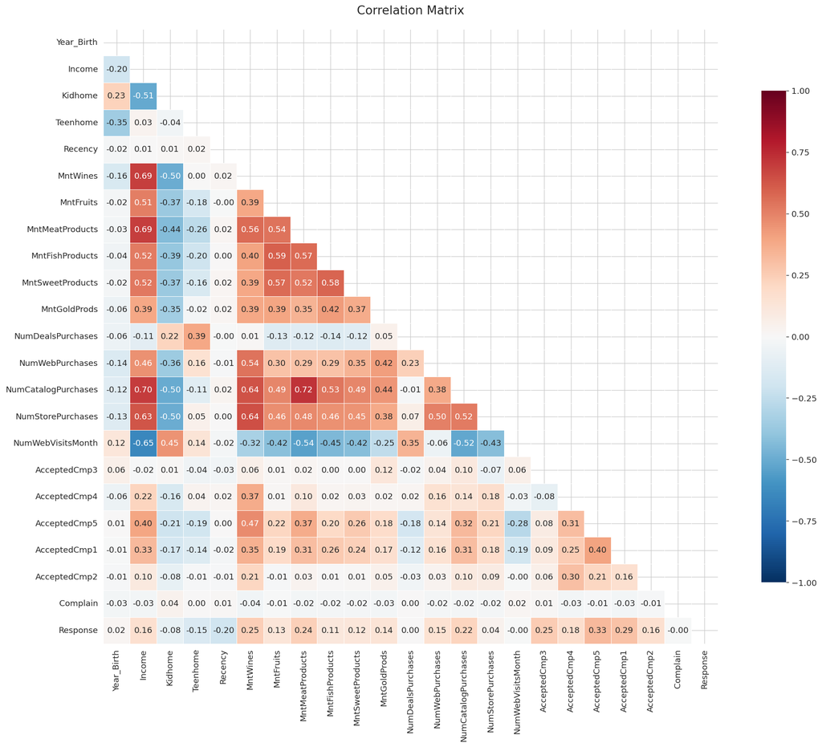

```python
# Correlation heatmap
plt.figure(figsize=(18, 14))
numeric_data = data.select_dtypes(include=[np.number])
mask = np.triu(np.ones_like(numeric_data.corr(), dtype=bool))
sns.heatmap(numeric_data.corr(), mask=mask, annot=True, vmin=-1, vmax=1, fmt=".2f",
            cmap="RdBu_r", square=True, linewidths=0.5, cbar_kws={"shrink": 0.8})
plt.title('Correlation Matrix', fontsize=16, pad=20)
plt.tight_layout()
plt.show()
```